# Итоговый проект

Группа 17

### Роли в команде:

- Софья: текстовый анализ
- Варя: сетевой анализ
- Феликс: построение модели CF и преобразование в функцию
- Артем: построение модели content - based и преобразование в функцию + сценарий для модели content-based после рецензии черновика отчета
- Маша: организация работы над проектом в целом(созвоны, распределение ролей, подведение промежуточных итогов) + оценивание качества моделей и тестирование их на примерах + ответы на вопросы из peer-review + подготовка презентации для видео + написание группового отчета

### Предобработка данных

Загрузка **датасета 7**

```r
load("~/shared/minor2_2023/data/project/metadata_g_7.RData")
```

После загрузки в имеем три таблицы: metadata, survey_answers, tags

Описание переменных:

`metadata`

- title – название
- directedBy – режиссер
- starring – актеры
- avgRating – средняя оценка на MovieLens
- imdbId – id на IMDb
- item_id – id фильма

`survey_answers` * item_id – id фильма * user_id – id пользователя * tag_id – id тега * score – уверенность пользователя в соответствии тега фильму

`tags` * tag – сам тег * id – id тега

Отзывы (появится датасет ratings), номер датасета также зависит от номера группы

```r
load("~/shared/minor2_2023/data/project/ratings_g_7.RData")
names(ratings)
```

```
## [1] "item_id" "user_id" "rating"
```

Загрузка необходимых **библиотек**

```r
library(ggpubr) #библиотеки на всякий случай

library(dplyr)
library(tidyr)
library(stopwords)
library(stringr)
library(tidyverse)
library(tidytext)
library(igraph)
library(ggraph)
library(recommenderlab)
library(wordcloud2)
```

### Текстовый анализ

Создаем датасет, в котором есть id фильма, для которого оставлен тег, сами теги и их оценки, и id пользователя, который оставил тег

```r
#объединяем данные из двух таблиц
tags_joined = full_join(tags, survey_answers, by = c("id" = "tag_id"))
#у каждого тега по несколько оценок, поэтому группируем по тегу и фильму, находим среднее
tags_mean = tags_joined %>% group_by(tag, item_id) %>% summarise(avrScore = mean(score))
```

```r
tags_mean_filt = tags_mean %>% filter(avrScore >= 4)
n_distinct(tags_mean_filt$item_id)
```

```
## [1] 158
```

Среди тегов ищем стоп-слова, если вдруг они есть

```r
stopwords = data.frame(tag=stopwords("en"), stringsAsFactors=FALSE)
tags_mean_filt = tags_mean_filt %>%
    anti_join(stopwords)
```

Стоп-слов среди тегов не обнаружено

Рисуем по полученным тегам облако слов, чтобы понимать, какие встречаются чаще всего(выбираем топ-50 тегоы)

```r
set.seed(1234)
avrTags.counts_filt = tags_mean_filt %>%
    dplyr::count(tag, sort=TRUE) %>%
    top_n(50, n)
second = wordcloud2(data = avrTags.counts_filt)
second
```

[interactive chart not shown]

Вывод: теги fairy tale, fantasy - напоминают названия жанров, однако остальные теги(например, alaska, business, devil) больше напоминают случайные ключевые слова по разным фильмам

Следовательно, большинство тегов уникальны и не могут быть использованы в качестве жанров.

Однако так же на облаке слов присутствуют оценочные слова, связанные с настроением фильма (например, sad, silly). Значит дальше можно поработать со словарем оценочной лексики и посмотреть на настроение фильмов.

Далее получим года выпуска фильма (данная информация о фильмах может пригодиться для создания системы content-based):

```r
metadata1 <- metadata
# вектор для хранения извлеченного года
years <- vector("character", length = nrow(metadata1))
# циклом проходимся и получаем год для каждого фильма, сохраняем в вектор
for (i in 1:nrow(metadata1)) {
  title <- metadata1$title[i]
  # задаем шаблон, по которому собираемся искать (который у нас и представлен)
  year_pattern <- "\\(\\d{4}\\)$"
  year_match <- str_match(title, year_pattern)
  if (!is.na(year_match)) {
    # извлекаем год и завершающие символы
    year_text <- year_match[[1]]
    trailing_chars <- year_match[[1]]
    # удаляем скобочки и завершающие символы
    years[i] <- gsub("(\\(|\\))", "", year_text)
    # проверка на то, что в завершающих символах только пробелы
    if (!all(str_trim(trailing_chars) == "")) {
      # если нет, то убираем лишнее
      years[i] <- paste0(years[i])
    }
  } else {
    years[i] <- NA # если не удалось излечь год, присваиваем NA
  }
}
# добавление получившегося вектора в столбец
metadata1$year <- years
```

Лемматизируем теги (вдруг что-то можно привести к изначальной форме, спойлер - ничего нового)

```r
tags_mean1 = tags_mean
subtotal <- system2("mystem", c("-c", "-l", "-d"), input = tags_mean1$tag, stdout=TRUE)
lemmatized_tags <- str_replace_all(subtotal, "\\{([^}]+?)([?]+)?\\}", "\\1")
tags_mean1 <- cbind(tags_mean1, lemtag = lemmatized_tags)
```

Однако ни к каким изменениям это не привело

Создаем матрицу и смотрим, какие у нас есть фильмы и какие теги в них встречаются

```r
tags_dtm = tags_mean1 %>%
  group_by(item_id) %>%
  dplyr::count(lemtag, sort=TRUE) %>%
  cast_sparse(item_id, lemtag, n) %>%
  as.matrix()
```

По косинусу угла смотрим, какие фильмы похожи (основываясь на тегах)

```r
cos_dist = lsa::cosine(t(tags_dtm))
```

Теперь проводим **сентимент-анализ**, используя словари **bing** и **afinn** Пояснение: сентимент-анализ проводился нами, так как вначале мы планировали наравне с тегами использовать информацию о настроении фильма в content-based модели (однако впоследствии решили использовать вместо них жанры и другую дополнительную информацию из датасета imdb)

```r
bing_dict = get_sentiments("bing")
afinn_dict = get_sentiments("afinn")
bingtags = tags_mean1 %>%
  inner_join(bing_dict, by= c("lemtag" = "word"))
library(ggplot2)
```

Рисуем график, чтобы посмотреть, каких тегов больше (позитивных или негативных):

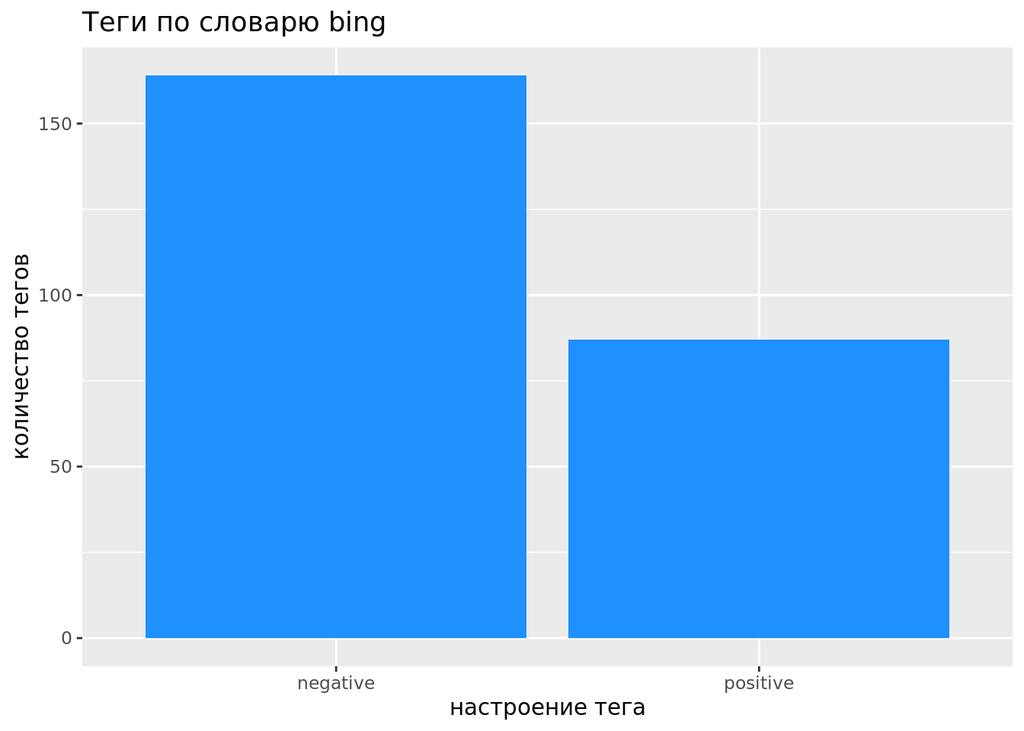

```r
ggplot() +
  geom_bar(data = bingtags, aes(x = sentiment), fill = "#1E90FF") +
ggtitle("Теги по словарю bing") + xlab("настроение тега") + ylab("количество тегов")
```

Визуализируем и видим, что **негативных тегов больше**

По другому словарю тоже строим график Оценки тегов варьируются от -5 до 5, где теги с оценкой -5 самые негативные, а теги с оценкой 5 самые позитивные

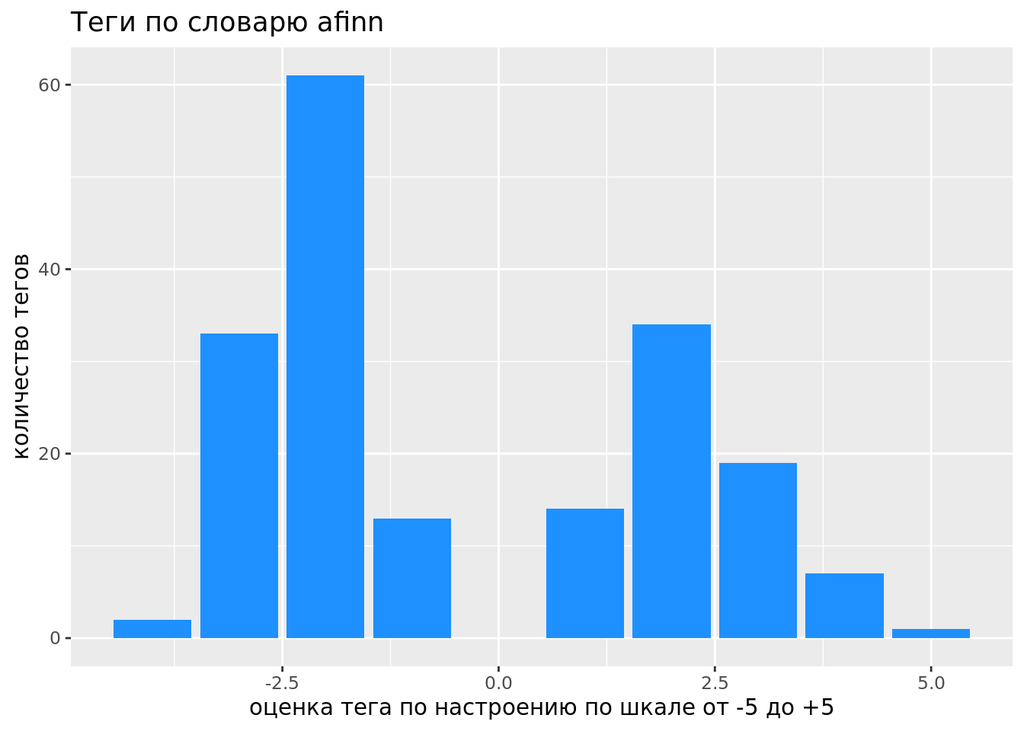

```r
afinntags = tags_mean1 %>%
  inner_join(afinn_dict, by= c("lemtag" = "word"))
ggplot() +
  geom_bar(data = afinntags, aes(x = value), fill = "#1E90FF") +
ggtitle("Теги по словарю afinn") + xlab("оценка тега по настроению по шкале от -5 до +5") + ylab("количество тегов")
```

Визуализируем и снова видим, что **негативных тегов больше** (причем больше всего умеренное негативных тегов с оценкой -2)

Скачиваем словарь оценочной лексики **nrc**, в котором эмоции расписаны поподробнее, чтобы получить более детально описаннные по эмоциям данные по фильмам

```r
nrc_dict = get_sentiments("nrc")
tags_nrc = tags_mean1 %>%
  inner_join(nrc_dict, by= c("lemtag" = "word")) #добавляем полученные данные к датасету
```

Строим график и смотрим на количество тегов с разным настроением

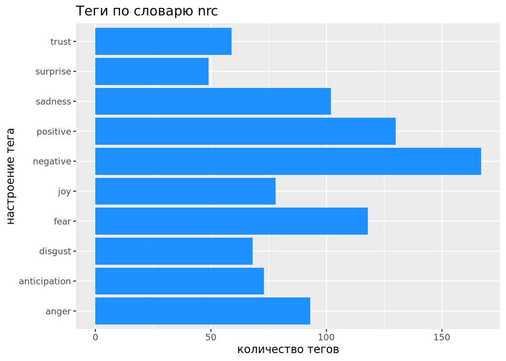

```r
ggplot() +
  geom_bar(data = tags_nrc, aes(x = sentiment), fill = "#1E90FF") +
ggtitle("Теги по словарю nrc") + xlab("настроение тега") + ylab("количество тегов") + coord_flip()
```

Так как теги оказались уникальными, что усложняет их использование для определения похожести фильмов, нами было принято решение в построении модели их не использовать.

Жанры выделить не получилось, и поэтому мы нашли дополнительные данные - датасет Imdb, в котором есть часть наших фильмов (в итоге их оказалось 372), и использовали их, чтобы получить жанры

```r
movies = "~/movies.csv"

genres3 <- read.csv(movies)
genres3 = genres3 %>% select(name, genre)
genres3 <- rename(genres3, title = name)

regex <- "\\(.*\\)"
new_titles <- gsub(regex, "", metadata1$title)
metadata1$title <- gsub("\\(.*\\)", "", new_titles)
metadata1$title <- str_trim(metadata1$title)

# Создадим новый столбец 'genre' в 'metadata'
metadata1$genre <- NA

# Пройдемся по каждому названию фильма в 'genres'
for (i in 1:nrow(genres3)) {
  # Получим текущее название фильма из 'genres'
  current_title <- genres3$title[i]

  # Проверим, есть ли это название в 'metadata1'
  if (any(metadata1$title == current_title)) {
    # Получим индекс совпадающего фильма в 'metadata1'
    matching_index <- which(metadata1$title == current_title)

    # Получим жанр фильма из 'genres'
    genre <- genres3$genre[i]

    # Добавим жанр в 'metadata1' с помощью ifelse()
    metadata1$genre[matching_index] <- ifelse(length(matching_index) > 0, genre, NA)
  }
}
```

Строим график и смотрим на количество фильмов разных жанров

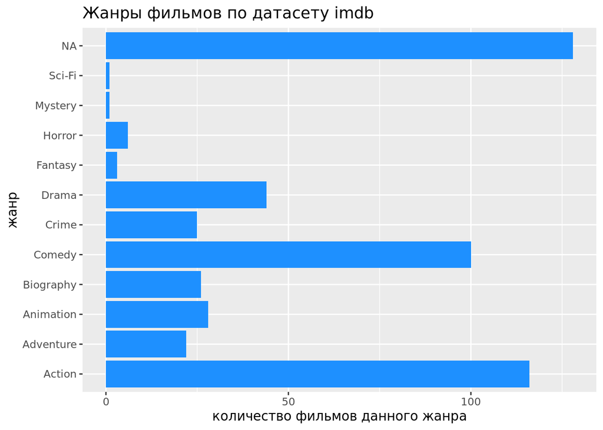

```r
ggplot() +
  geom_bar(data = metadata1, aes(x = genre), fill = "#1E90FF") +
ggtitle("Жанры фильмов по датасету imdb") + xlab("жанр") + ylab("количество фильмов данного жанра") + coord_flip()
```

Вывод: в выборке преобладают фильмы жанров экшн и комедия

### Сетевой анализ

Мы решили провести сетевой анализ, чтобы в ходе него разделить фильмы на сообщества по значимым характеристикам(режиссер, актер в главной роли, сценарист, кинокомпания, страна производства) и в дальнейшем использовать полученное разделение при построении модели content-based.

Загружаем данные:

```r
metadata1 = metadata
 genres3 <- read.csv(movies)
 genres3 = genres3 %>% select(name, genre, star, writer, country, company, year)
 genres3 <- rename(genres3, title = name)
```

Избавляемся от лишних символов в названиях фильмов:

```r
regex <- "\\(.*\\)"
 new_titles <- gsub(regex, "", metadata1$title)
 metadata1$title <- gsub("\\(.*\\)", "", new_titles)
 metadata1$title <- str_trim(metadata1$title)
```

Создадим новый столбец ‘genre’ и ‘star’ в ‘metadata1’

```r
metadata1$genre <- NA
 metadata1$star <- NA
 metadata1$writer <- NA
 metadata1$company <- NA
 metadata1$country <- NA
 metadata1$year <- NA
```

Пройдемся по каждому названию фильма в ‘genres’

```r
 for (i in 1:nrow(genres3)) {
   # Получим текущее название фильма из 'genres'
   current_title <- genres3$title[i]

   # Проверим, есть ли это название в 'metadata1'
   if (any(metadata1$title == current_title)) {
     # Получим индекс совпадающего фильма в 'metadata1'
     matching_index <- which(metadata1$title == current_title)

     # Получим нужные параметры фильма из 'genres'
     genre <- genres3$genre[i]
     star = genres3$star[i]
     writer <- genres3$writer[i]
     country = genres3$country[i]
     company = genres3$company[i]
     year = genres3$year[i]

     # Добавим жанр в 'metadata1' с помощью ifelse()
     metadata1$genre[matching_index] <- ifelse(length(matching_index) > 0, genre, NA)
     metadata1$star[matching_index] <- ifelse(length(matching_index) > 0, star, NA)
     metadata1$company[matching_index] <- ifelse(length(matching_index) > 0, company, NA)
     metadata1$country[matching_index] <- ifelse(length(matching_index) > 0, country, NA)
     metadata1$writer[matching_index] <- ifelse(length(matching_index) > 0, writer, NA)
     metadata1$year[matching_index] <- ifelse(length(matching_index) > 0, year, NA)
   }
 }
```

```r
library(igraph)
 library(dplyr)
 library(tidyverse)
 library(visNetwork)

 metadata1 = "~/metadata1_net_new.csv"
 net_data = read.csv(metadata1)
```

Создание матрицы смежности

```r
 adj_matrix = matrix(0, nrow = length(net_data$title), ncol = length(net_data$title))
 rownames(adj_matrix) = net_data$title
 colnames(adj_matrix) = net_data$title
```

Заполнение матрицы смежности на основе общих параметров с помощью цикла for:

```r
for (i in 1:(length(net_data$title) - 1)) {
   for (j in (i + 1):length(net_data$title)) {

     #Обработка случаев, когда один из параметров NA
     if (is.na(net_data$directedBy[i]) || is.na(net_data$directedBy[j])) drctr = 0 else drctr = net_data$directedBy[i] == net_data$directedBy[j]

     if (is.na(net_data$company[i]) || is.na(net_data$company[j])) cmpn = 0 else cmpn = net_data$company[i] == net_data$company[j]

     if (is.na(net_data$genre[i]) || is.na(net_data$genre[j])) gnr = 0 else gnr = net_data$genre[i] == net_data$genre[j]

     if (is.na(net_data$country[i]) || is.na(net_data$country[j])) cntr = 0 else cntr = net_data$country[i] == net_data$country[j]

     if (is.na(net_data$star[i]) || is.na(net_data$star[j])) str = 0 else str = net_data$star[i] == net_data$star[j]

     if (is.na(net_data$writer[i]) || is.na(net_data$writer[j]))   wrtr = 0 else wrtr = net_data$writer[i] == net_data$writer[j]

     #Формула для определения "похожести" фильмов
     common = 5 * (str + gnr) + 2 * (drctr + wrtr) + 0.5 * (cmpn + cntr)

     adj_matrix[i, j] = common
     adj_matrix[j, i] = common
   }
 }
```

Преобразование матрицы смежности в граф

```r
g = graph_from_adjacency_matrix(adj_matrix, mode = "undirected", weighted = TRUE)

 clusters = cluster_walktrap(g)
```

Получение кластеров для каждого узла

```r
membership = membership(clusters)

 net_data$group = membership
```

Добавление кластера для каждого фильма в исходный датасет

```r
metadata1_net = net_data
```

Сохранение полученного датасета в файл metadata1_net

```r
 write.csv(metadata1_net, "metadata1_net.csv", row.names = FALSE)
```

### Коллаборативная фильтрация(метод ICBF)

```r
library(tidyverse)
```

Посмотрим общее число выставленных оценок

```r
nrow(ratings)
```

```
## [1] 35235
```

Посмотрим на пользователей, как они оценивали фильмы:

```r
counts = ratings %>% count(user_id)
counts %>% top_n(5, n) %>% arrange(-n)
```

```
## # A tibble: 7 × 2
##   user_id     n
##     <dbl> <int>
## 1  176194    59
## 2  376607    54
## 3  105213    53
## 4  928461    53
## 5   70490    45
## 6  547540    45
## 7  960005    45
```

Вывод: самое большое число оценок - 60, самое меньшее - 6

Создадим табличку:

```r
library(tidyr)
rates = pivot_wider(ratings, names_from = item_id, values_from = rating)
```

Удалим айдишники пользователей

```r
userNames = rates$user_id
rates = select(rates, -user_id)
```

Подключим библиотеку и начнём строить модель:

```r
library(recommenderlab)
# преобразование таблицы данных в матрицу
rates = as.matrix(rates)
rownames(rates) = userNames
# преобразование матрицы в realRatingMatrix
r = as(rates, "realRatingMatrix", strict = T)
r
```

```
## 3000 x 500 rating matrix of class 'realRatingMatrix' with 35235 ratings.
```

Посмотрим на то, сколько в среднем оценок у одного фильма:

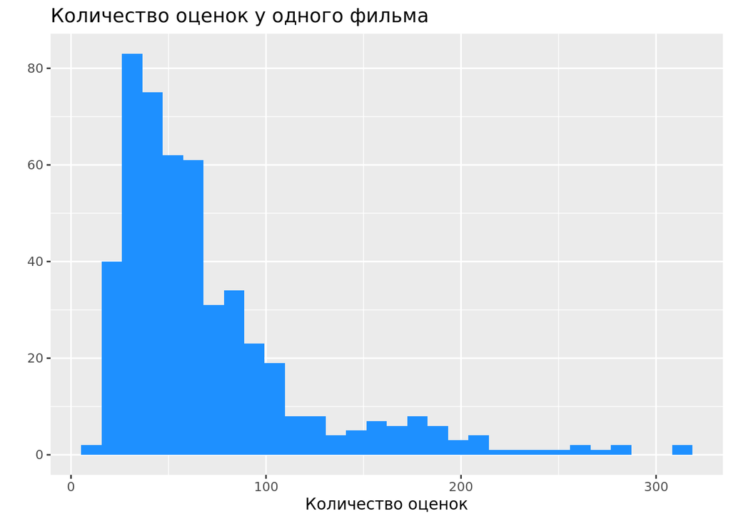

```r
ggplot(data = data.frame(filmRate=colCounts(r))) + geom_histogram(aes(x=filmRate), fill = "#1E90FF") +
ggtitle("Количество оценок у одного фильма") + xlab("Количество оценок") + ylab("")
```

Посмотрим на то, сколько в среднем оценок у одного пользователя:

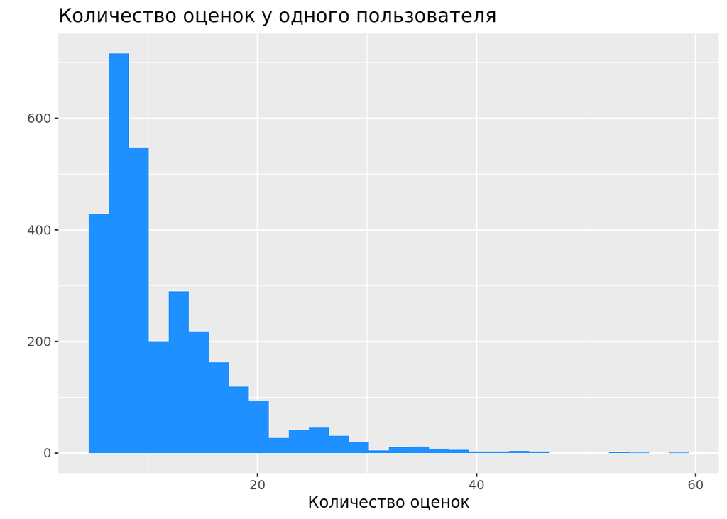

```r
ggplot(data = data.frame(userRate=rowCounts(r))) + geom_histogram(aes(x=userRate), fill = "#1E90FF") +
ggtitle("Количество оценок у одного пользователя") + xlab("Количество оценок") + ylab("")
```

Отфильтруем данные:

```r
ratings_movies <- r[rowCounts(r) > 5, colCounts(r) > 10]
ratings_movies
```

```
## 3000 x 500 rating matrix of class 'realRatingMatrix' with 35235 ratings.
```

И построим график распределения средних оценок пользователей:

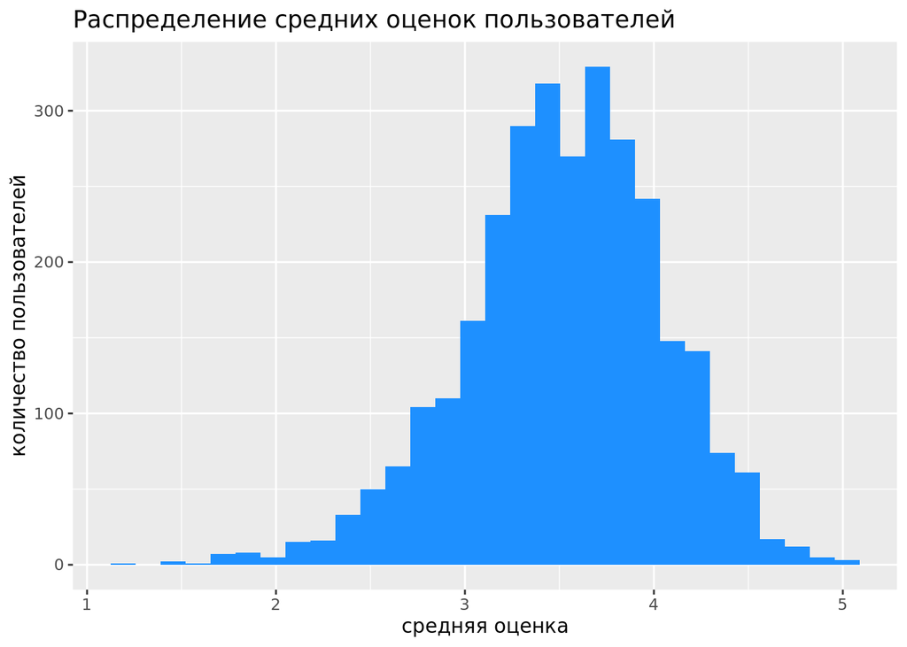

```r
average_ratings_per_user <- rowMeans(ratings_movies)
ggplot()+geom_histogram(aes(x=average_ratings_per_user), fill = "#1E90FF") +
ggtitle("Распределение средних оценок пользователей") + xlab("средняя оценка") + ylab("количество пользователей")
```

Исходя из графика, можно сделать вывод о том, что средняя оценка фильмов у отдельного пользователя в среднем около 3.5

Посмотрели на пользователей, теперь приступим к самому методу CF

**Коллаборативная фильтрация:**

Делим на тестовую и обучающую выборки:

```r
set.seed(100)
test_ind <- sample(1:nrow(ratings_movies), size = nrow(ratings_movies)*0.2)
recc_data_train <- ratings_movies[-test_ind, ]
recc_data_test <- ratings_movies[test_ind, ]
```

Строим рекомендательную модель:

```r
recc_model <- Recommender(data = recc_data_train, method = "IBCF")
recc_model
```

```
## Recommender of type 'IBCF' for 'realRatingMatrix'
## learned using 2400 users.
```

Создаем матрицу схожести фильмов

```r
model_details <- getModel(recc_model)
model_details$description
```

```
## [1] "IBCF: Reduced similarity matrix"
```

```r
model_details$sim[1:10, 1:10]
```

```
## 10 x 10 sparse Matrix of class "dgCMatrix"
##
## 112852 . . . . . . . . . .
## 2355   . . . . . . . . . .
## 2083   . . . . . . . . . .
## 32587  . . . . . . . . . .
## 2628   . . . . . . . . . .
## 3793   . . . . . . . . . .
## 173    . . . . . . . . . .
## 91077  . . . . . . . . . .
## 1372   . . . . . . . . . .
## 4014   . . . . . . . . . .
```

Теперь проведём тест, предскажем по 6 фильмов для каждого пользователя

```r
recc_predicted <- predict(object = recc_model, newdata = ratings_movies, n = 6)
recc_predicted
```

```
## Recommendations as 'topNList' with n = 6 for 3000 users.
```

Создадим функцию, чтобы добавить последнюю строку в данных для нового пользователя для основной функции:

```r
fill_last_row <- function(rates, userID, ratings) {
  last_row_index <- nrow(rates)

  for (i in seq_along(userID)) {
    column_name <- userID[i]
    rating_value <- ratings[i]

    if (column_name %in% colnames(rates)) {
      column_index <- which(colnames(rates) == column_name)
      rates[last_row_index, column_index] <- rating_value
    }
  }

  return(rates)
}
```

Сохраним ID пользователей, чтоб искать удобнее было

```r
names(recc_predicted@items) = rownames(ratings_movies)
```

**Рекомендательная функция CF**

```r
get_recommendations <- function(userID, filmsID, ratings) {
  if (userID %in% rownames(rates)){
    recc_user <- recc_predicted@items[[userID]]
    movies_user <- recc_predicted@itemLabels[recc_user]
  }
  else {
    rates <- rbind(rates, rep(NA, ncol(rates)))
    rownames(rates)[nrow(rates)] <- userID
    rates <- fill_last_row(rates, filmsID, ratings)
    user_ratings_matrix <- as(rates, "realRatingMatrix", strict = T)
    recommendations <- predict(object = recc_model, newdata = user_ratings_matrix, n = 6)

    recc_user <- recommendations@items[[userID]]
    movies_user <- recommendations@itemLabels[recc_user]
  }
  return(movies_user)
}
```

Таким образом, полученная нами модель CF в случае, если пользователя нет в данных, добавляет данные про его id, id фильмов, которые он оценил и непосредственно данные об оценках в датасет и дальше работает по стандартному алгоритму.

Перед оценкой качества рекомендаций отфильтруем датасет, чтобы в нем были только фильмы с жанрами:

```r
metadata <- read.csv("metadata1_net.csv")
metadata = metadata %>% drop_na(genre)
```

Итоговый датасет, с которым мы будем работать в процессе оценки работы моделей называется metadata

**Оценивание рекомендации:**

**Внутренняя пользовательская оценка**

Для начала попробуем внести в функцию данные по одному пользователю из имеющегося датасета, а именно его id, вектор с id фильмов, которые он оценил, и вектор с оценками данных фильмов

```r
for_ibcf = ratings %>% filter(user_id == "138823") #отфильтровываем данные по одному пользователю из таблицы с оценками фильмов
filmsID_vec = for_ibcf  %>% select(item_id) %>% pull() #создаем вектор с id фильмов
ratings_vector = for_ibcf  %>% select(rating) %>% pull() #создаем вектор с оценками фильмов
```

```r
counts %>% filter(user_id == "138823")
```

```
## # A tibble: 1 × 2
##   user_id     n
##     <dbl> <int>
## 1  138823    10
```

Выведем данные по одному пользователю

```r
for_ibcf %>% inner_join(metadata, by = "item_id") %>% select(title,rating,genre)
```

```
## # A tibble: 7 × 3
##   title                                   rating genre
##   <chr>                                    <dbl> <chr>
## 1 Guardians of the Galaxy                    3.5 Action
## 2 Sunshine                                   4   Sci-Fi
## 3 The Intern                                 3   Comedy
## 4 Harry Potter and the Chamber of Secrets    0.5 Adventure
## 5 Schindler's List                           4   Biography
## 6 Sicario                                    3.5 Action
## 7 Equilibrium                                5   Action
```

Пробуем применить рекомендательную систему CF:

```r
get_recommendations("138823", filmsID_vec, ratings_vector)
```

```
## [1] "55765"  "115149" "539"    "1580"   "356"    "56782"
```

```r
recc_predicted@items[["138823"]]
```

```
## [1] 14 15 19 34 39 59
```

Посмотрим на фильмы, которые порекомендовала пользователю функция:

```r
metadata %>% filter(item_id == "55765") %>% select(title,genre)
```

```
##               title     genre
## 1 American Gangster Biography
```

```r
metadata %>% filter(item_id == "115149") %>% select(title,genre)
```

```
##       title  genre
## 1 John Wick Action
```

```r
metadata %>% filter(item_id == "539") %>% select(title,genre)
```

```
##                  title  genre
## 1 Sleepless in Seattle Comedy
```

```r
metadata %>% filter(item_id == "1580") %>% select(title,genre)
```

```
##          title  genre
## 1 Men in Black Action
```

```r
metadata %>% filter(item_id == "356") %>% select(title,genre)
```

```
##          title genre
## 1 Forrest Gump Drama
```

```r
metadata %>% filter(item_id == "56782") %>% select(title,genre)
```

```
##                 title genre
## 1 There Will Be Blood Drama
```

Таким образом, пользователю были рекомендованы фильмы:

1. “Американский ганстер”(biography)
2. “Джон Уик” (action)
3. “Неспящие в Сиэттле”(comedy)
4. “Люди в черном”(action)
5. “Форрест Гамп” (drama)
6. “Нефть”(drama)

**Оценка качества рекомендаций:**

Проверим

```r
table(metadata$genre)
```

```
##
##    Action Adventure Animation Biography    Comedy     Crime     Drama   Fantasy
##       116        22        28        26       100        25        44         3
##    Horror   Mystery    Sci-Fi
##         6         1         1
```

Это правда так - в выборке c 372 фильмами остался только один фильм жанра Sci-Fi :(

### Content-based рекомендация

```r
metadata = metadata %>% drop_na(genre) %>% dplyr::select(-company, -writer, -country, -star)
```

Мы решили сделать content-based рекомендательную систему, в которой пользователь вводит название фильма, а система выдает ему похожие. Чтобы это реализовать, выберем интересующие нас характеристики для сравнения, и преобразуем их в числовые значения. Таким образом можно будет построить матрицу схожести, и на ее основе рекомендовать фильмы.

Так как мы решили, что режиссеры и актеры могут помочь в определении схожести фильмов, то придется создать для каждого актера и режиссера столбец и заполнять его единицой в случае присутствия этого человека в фильме, и нулем в противном случае.

```r
metadata_sep <- metadata %>% separate_rows(starring, sep = ", ")

metadata_sep <- metadata_sep %>%
  mutate(actors_v = 1)
metadata <- metadata %>%
  mutate(directedBy_v = 1)
metadata <- metadata %>%
  mutate(genre_v = 1)

metadata_sep = metadata_sep %>% rename(actors_sep = starring) %>% filter(actors_sep != "")

data = metadata_sep %>% pivot_wider(names_from = actors_sep, values_from = actors_v, values_fill = 0)

data_genres = metadata %>% pivot_wider(names_from = genre, values_from = genre_v, values_fill = 0)

data_dirs = metadata %>%
  separate_rows(directedBy, sep = ", ") %>%
  rename(directed_sep = directedBy) %>%
  filter(directed_sep != "")

data_dirs = data_dirs %>% pivot_wider(names_from = directed_sep, values_from = directedBy_v, values_fill = 0)
```

```r
data_dirs = data_dirs %>% dplyr::select(-avgRating, -starring, -title, -imdbId, -year, -genre, -genre_v)
data_genres = data_genres %>% dplyr::select(-avgRating, -starring, -title, -imdbId, -year, -directedBy_v, -directedBy)
# data = data %>% dplyr::select(-directedBy)
data = data %>% dplyr::select(-directedBy, -avgRating)
data = inner_join(data, data_dirs, by='item_id')
data = inner_join(data, data_genres, by='item_id')
```

```r
data$year <- as.numeric(data$year)
data = data %>% dplyr::select(-title, -imdbId, -genre, -year)
rownames = data$item_id
data = data %>% dplyr::select(-item_id)
rownames(data) = rownames
sim = lsa::cosine(t(as.matrix(data)))
diag(sim) = 0
```

Теперь найдем жанры, чтобы добавить в функцию доступные.

```r
available_genres = unique(metadata$genre)
print(unique(metadata$genre))
```

```
##  [1] "Drama"     "Comedy"    "Crime"     "Action"    "Adventure" "Biography"
##  [7] "Horror"    "Animation" "Fantasy"   "Mystery"   "Sci-Fi"
```

Теперь создаем функцию. Сама функция принимает на вход название фильма, жанр и число рекомендаций. Внутри сначала идет проверка на наличие фильма в базе, и в противном случае пытается проверить, если пользователь ввел название не до конца.

При введении жанра также проверяется, есть ли такой жанр среди фильмов, и если есть, то использует его. Без ввведения жанра ввыводящиеся фильмы могут быть любого жанра.

```r
contentBasedRecommendation <- function(name, genre='', count=3) {
  if (any(metadata$title == name) == FALSE) {
    print('Нет фильмов с таким названием.')
    similar_name_search = subset(metadata, grepl(name, title, ignore.case=TRUE))$title
    if (length(similar_name_search) > 0) {
      print('Возможно вы имели в виду:')
      cat(subset(metadata, grepl(name, title, ignore.case=TRUE))$title, sep = "\n")
    }
    return()
  }

  cur_metadata = metadata

  input_movie = subset(metadata, title == name)$item_id

  if (genre != '') {
    if (!(genre %in% available_genres)) {
      print("Такого жанра нет")
      return()
    }
  }

  # mostSimilar = head(sort(sim[,as.character(input_movie)], decreasing = T), n = count)
  mostSimilar = sort(sim[,as.character(input_movie)], decreasing = T)

  mostSimilar = data.frame(similar = mostSimilar)
  mostSimilar$item_id = as.numeric(rownames(mostSimilar))

  if (genre != '') {
    cur_genre = genre
    mostSimilar = mostSimilar %>% left_join(metadata) %>% select(item_id, title, similar, genre, year) %>% arrange(-similar) %>% filter(genre == cur_genre)

  } else {
    mostSimilar = mostSimilar %>% left_join(metadata) %>% select(item_id, title, similar, genre, year) %>% arrange(-similar)
  }

  head(mostSimilar, n = count)
}
```

**Оценивание рекомендации:**

Внутренняя пользовательская оценка

Введем в функцию в качестве входных данных “Skyfall”(название фильма), genre=‘Action’(жанр) и count=10 (количество рекомендаций)

```r
contentBasedRecommendation("Skyfall", genre='Action', count=10)
```

```
##    item_id                                      title   similar  genre year
## 1   111781         Mission: Impossible - Rogue Nation 0.8932746 Action 2015
## 2   135569                           Star Trek Beyond 0.8932746 Action 2016
## 3   122904                                   Deadpool 0.8932746 Action 2016
## 4   166528               Rogue One: A Star Wars Story 0.8932746 Action 2016
## 5   122886 Star Wars: Episode VII - The Force Awakens 0.8932746 Action 2015
## 6   116823      The Hunger Games: Mockingjay - Part 1 0.8932746 Action 2014
## 7   139644                                    Sicario 0.8932746 Action 2015
## 8   174055                                    Dunkirk 0.8932746 Action 2017
## 9   143355                               Wonder Woman 0.8932746 Action 2017
## 10  158238                              The Nice Guys 0.8932746 Action 2016
```

Пользователю, которому нравится фильм Skyfall жанра Action, функция вывела в качестве рекомендаций фильмы того же жанра с высокими показателями схожести(которая оценивается на основе режиссеров, актеров, жанров и кластеров фильмов, выделенных в ходе сетевого анализе) равной 0.89 и выше, что говорит о том, что полученные фильмы довольно похожи на тот, который нравится пользователю, и рекомендации получились хорошие.

Если ввести в функцию “Skyfall”(название фильма) и жанр Crime, не соответствующий истинному жанру фильма, результат будет иным:

```r
contentBasedRecommendation("Skyfall", genre='Crime', count=10)
```

```
##    item_id             title   similar genre year
## 1   128360 The Hateful Eight 0.6377928 Crime 2015
## 2      628       Primal Fear 0.5207556 Crime 1996
## 3     6953          21 Grams 0.5207556 Crime 2003
## 4      481        Kalifornia 0.5207556 Crime 1993
## 5     1343         Cape Fear 0.5207556 Crime 1991
## 6    58803                21 0.5207556 Crime 2008
## 7     3510         Frequency 0.5207556 Crime 2000
## 8     2881   Double Jeopardy 0.5207556 Crime 1999
## 9    52604          Fracture 0.4940322 Crime 2007
## 10    5266        Panic Room 0.4940322 Crime 2002
```

### Примеры

##### Примеры collaborative filtering

Рассмотрим сценарии,при котором у пользователя а) нет оценок

данный сценарий мы рассмотреть не можем, так как наша модель его не предусматривает и работает только с пользователями, у которых есть оценки

б) все оценки низкие и средняя оценка следовательно тоже низкая

```r
for_ibcf_vse_niz = ratings %>% group_by(user_id) %>% mutate(mean_score = mean(rating)) %>% arrange(mean_score)
for_ibcf_vse_niz
```

```
## # A tibble: 35,235 × 4
## # Groups:   user_id [3,000]
##    item_id user_id rating mean_score
##      <dbl>   <dbl>  <dbl>      <dbl>
##  1    4370  871551    1         1.17
##  2    2628  871551    0.5       1.17
##  3   87430  871551    0.5       1.17
##  4   53996  871551    1.5       1.17
##  5   88140  871551    0.5       1.17
##  6    4993  871551    3         1.17
##  7    6659  833093    1.5       1.43
##  8      48  833093    0.5       1.43
##  9       1  833093    0.5       1.43
## 10    4878  833093    3         1.43
## # ℹ 35,225 more rows
```

id нужного нам пользователя - 871551

```r
for_ibcf_871551 = ratings %>% filter(user_id == "871551") #отфильтровываем данные по одному пользователю из таблицы с оценками фильмов
filmsID_vec_871551 = for_ibcf_871551  %>% select(item_id) %>% pull() #создаем вектор с id фильмов
ratings_vector_871551 = for_ibcf_871551  %>% select(rating) %>% pull() #создаем вектор с оценками фильмов
```

```r
for_ibcf_871551
```

```
## # A tibble: 6 × 3
##   item_id user_id rating
##     <dbl>   <dbl>  <dbl>
## 1    4370  871551    1
## 2    2628  871551    0.5
## 3   87430  871551    0.5
## 4   53996  871551    1.5
## 5   88140  871551    0.5
## 6    4993  871551    3
```

Тестируем с помощью функции CF

```r
get_recommendations("871551", filmsID_vec_4370, ratings_vector_4370)
```

```
## [1] "1372"   "4014"   "115149" "1717"   "112556" "97923"
```

Посмотрим на фильмы, которые пользователь оценил:

```r
for_ibcf_871551 %>% inner_join(metadata, by = "item_id") %>% select(title,rating,genre)
```

```
## # A tibble: 4 × 3
##   title                                     rating genre
##   <chr>                                      <dbl> <chr>
## 1 A.I. Artificial Intelligence                 1   Drama
## 2 Star Wars: Episode I - The Phantom Menace    0.5 Action
## 3 Green Lantern                                0.5 Action
## 4 Transformers                                 1.5 Action
```

Таким образом, пользователь оценил фильмы следующим образом: 1) “Искусственный разум”(drama) - 1.0 2) “Звёздные войны. Эпизод 1: Скрытая угроза”(action) - 0.5 3) “Зелёный фонарь”(action) - 0.5 4) “Трансформеры”(action) - 1.5

Сравним с фильмами, которые порекомендовала ему функция:

```r
metadata %>% filter(item_id == "1372") %>% select(title,genre)
```

```
##                                    title  genre
## 1 Star Trek VI: The Undiscovered Country Action
```

```r
metadata %>% filter(item_id == "4014") %>% select(title,genre)
```

```
##      title genre
## 1 Chocolat Drama
```

```r
metadata %>% filter(item_id == "115149") %>% select(title,genre)
```

```
##       title  genre
## 1 John Wick Action
```

```r
metadata %>% filter(item_id == "1717") %>% select(title,genre)
```

```
##      title  genre
## 1 Scream 2 Horror
```

```r
metadata %>% filter(item_id == "112556") %>% select(title,genre)
```

```
##       title genre
## 1 Gone Girl Drama
```

```r
metadata %>% filter(item_id == "97923") %>% select(title,genre)
```

```
##    title genre
## 1 Flight Drama
```

Таким образом, пользователю были рекомендованы фильмы:

1. “Стартрек 6”(Action)
2. “Шоколад”(Drama)
3. “Джон Уик”(Action)
4. “Крик 2”(Horror)
5. “Исчезнувшая” (Drama)
6. “Полет”(Drama)

**Оценка качества рекомендаций:**

Если пользователь оценивает низко фильмы определенного жанра, то мы ждем от рекомендательной системы, что она не будет предлагать пользователю фильмы такого же жанра, а предложит другие фильмы, непохожие на те,которые пользователь оценил низко

Пользователю,который низко оценил фильмы жанра action и drama, были рекомендованы фильма жанра action и drama, что мы не ждали от функции. Здесь она работает не так, как должна была бы.

в) все оценки высокие и средняя оценка следовательно тоже высокая

```r
for_ibcf_vse_vis = ratings %>% group_by(user_id) %>% mutate(mean_score = mean(rating)) %>% arrange(-mean_score)
for_ibcf_vse_vis
```

```
## # A tibble: 35,235 × 4
## # Groups:   user_id [3,000]
##    item_id user_id rating mean_score
##      <dbl>   <dbl>  <dbl>      <dbl>
##  1    2628  321346      5          5
##  2   94777  321346      5          5
##  3    6709  321346      5          5
##  4    8807  321346      5          5
##  5   45722  321346      5          5
##  6    6953  671196      5          5
##  7     410  321346      5          5
##  8    4306  671196      5          5
##  9   52722  671196      5          5
## 10   46970  321346      5          5
## # ℹ 35,225 more rows
```

id нужного нам пользователя - 321346

```r
for_ibcf_321346 = ratings %>% filter(user_id == "321346") #отфильтровываем данные по одному пользователю из таблицы с оценками фильмов
filmsID_vec_321346 = for_ibcf_321346  %>% select(item_id) %>% pull() #создаем вектор с id фильмов
ratings_vector_321346= for_ibcf_321346  %>% select(rating) %>% pull() #создаем вектор с оценками фильмов
```

```r
for_ibcf_321346
```

```
## # A tibble: 25 × 3
##    item_id user_id rating
##      <dbl>   <dbl>  <dbl>
##  1    2628  321346      5
##  2   94777  321346      5
##  3    6709  321346      5
##  4    8807  321346      5
##  5   45722  321346      5
##  6     410  321346      5
##  7   46970  321346      5
##  8  103042  321346      5
##  9   63992  321346      5
## 10   85510  321346      5
## # ℹ 15 more rows
```

Тестируем с помощью функции CF

```r
get_recommendations("321346", filmsID_vec_4370, ratings_vector_4370)
```

```
## [1] "2083"  "32587" "3793"  "91077" "1372"  "4014"
```

Посмотрим на фильмы, которые пользователь оценил:

```r
for_ibcf_321346 %>% inner_join(metadata, by = "item_id") %>% select(title,rating,genre)
```

```
## # A tibble: 21 × 3
##    title                                      rating genre
##    <chr>                                       <dbl> <chr>
##  1 Star Wars: Episode I - The Phantom Menace       5 Action
##  2 Once Upon a Time in Mexico                      5 Action
##  3 Pirates of the Caribbean: Dead Man's Chest      5 Action
##  4 Addams Family Values                            5 Comedy
##  5 Man of Steel                                    5 Action
##  6 Twilight                                        5 Drama
##  7 Sucker Punch                                    5 Action
##  8 Her                                             5 Drama
##  9 Cloud Atlas                                     5 Action
## 10 Over the Hedge                                  5 Animation
## # ℹ 11 more rows
```

Таким образом, пользователь оценил фильмы следующим образом(здесь приведем лишь часть из 21 фильма, для которых есть оценки): 1) “Звёздные войны. Эпизод 1: Скрытая угроза”(action) - 5.0

И сравним с теми, которые порекомендовала ему функция:

```r
metadata %>% filter(item_id == "2083") %>% select(title,genre)
```

```
## [1] title genre
## <0 rows> (or 0-length row.names)
```

```r
metadata %>% filter(item_id == "32587") %>% select(title,genre)
```

```
##      title genre
## 1 Sin City Crime
```

```r
metadata %>% filter(item_id == "3793") %>% select(title,genre)
```

```
##   title  genre
## 1 X-Men Action
```

```r
metadata %>% filter(item_id == "91077") %>% select(title,genre)
```

```
## [1] title genre
## <0 rows> (or 0-length row.names)
```

```r
metadata %>% filter(item_id == "1372") %>% select(title,genre)
```

```
##                                    title  genre
## 1 Star Trek VI: The Undiscovered Country Action
```

```r
metadata %>% filter(item_id == "4014") %>% select(title,genre)
```

```
##      title genre
## 1 Chocolat Drama
```

Таким образом, пользователю были рекомендованы фильмы:

1. “Город грехов”(сrime)
2. “Люди Икс”(action)
3. “Звёздный путь 6: Неоткрытая страна” (action)
4. “Шоколад”(drama)

**Оценка качества рекомендаций:**

Если пользователь оценивает высоко фильмы определенного жанра, то мы ждем от рекомендательной системы, что она будет предлагать пользователю фильмы такого же жанра

Наш пользователь оценил все фильмы на 5.0. Среди фильмов, которые он оценил преобладают фильмы жанров Animation, Comedy, Action, Drama, Crime. Следовательно, мы ждем от рекомендательной системы,что она порекомендует пользователю похожие фильмы таких же жанров. Так и произошло, значит рекомендательная система с задачей справилась.

Вышерассмотренные примеры б) и в) обобщают примеры, предложенные в нескольких отзывах в **peer review**

Отдельно рассмотрим сценарий, при котором для всех фильмов жанра crime пользователь поставил низкие оценки

Для начала еще раз обратимся к таблице с оценками меньше 3

```r
for_ibcf_vse_niz %>% arrange(mean_score)
```

```
## # A tibble: 35,235 × 4
## # Groups:   user_id [3,000]
##    item_id user_id rating mean_score
##      <dbl>   <dbl>  <dbl>      <dbl>
##  1    4370  871551    1         1.17
##  2    2628  871551    0.5       1.17
##  3   87430  871551    0.5       1.17
##  4   53996  871551    1.5       1.17
##  5   88140  871551    0.5       1.17
##  6    4993  871551    3         1.17
##  7    6659  833093    1.5       1.43
##  8      48  833093    0.5       1.43
##  9       1  833093    0.5       1.43
## 10    4878  833093    3         1.43
## # ℹ 35,225 more rows
```

Для пользователя 871551 мы уже смотрели рекомендации и к тому же среди оцененных им фильмов не было фильмов жанра Crime. У следующего в данной таблице пользователя 833093 слишком мало оценок и среди них тоже вероятнее всего может не оказаться фильмов жанра Crime.

Тогда проверяем пользователя с id = 343450

```r
for_ibcf_343450 = ratings %>% filter(user_id == "343450") #отфильтровываем данные по одному пользователю из таблицы с оценками фильмов
filmsID_vec_343450 = for_ibcf_343450  %>% select(item_id) %>% pull() #создаем вектор с id фильмов
ratings_vector_343450 = for_ibcf_343450  %>% select(rating) %>% pull() #создаем вектор с оценками фильмов
```

Посмотрим на фильмы жанра Crime, которые оценил пользователь:

```r
for_ibcf_343450 %>% inner_join(metadata, by = "item_id") %>% select(title,rating,genre) %>% filter(genre == "Crime")
```

```
## # A tibble: 1 × 3
##   title        rating genre
##   <chr>         <dbl> <chr>
## 1 Run Lola Run    0.5 Crime
```

Тестируем с помощью функции CF

```r
get_recommendations("343450",filmsID_vec_343450,ratings_vector_343450)
```

```
## [1] "60126" "1544"  "2359"  "2706"  "3176"  "96588"
```

Посмотрим на фильмы, которые порекомендовала ему функция:

```r
metadata %>% filter(item_id == "60126") %>% select(title,genre)
```

```
##       title  genre
## 1 Get Smart Action
```

```r
metadata %>% filter(item_id == "1544") %>% select(title,genre)
```

```
## [1] title genre
## <0 rows> (or 0-length row.names)
```

```r
metadata %>% filter(item_id == "2359") %>% select(title,genre)
```

```
##               title  genre
## 1 Waking Ned Devine Comedy
```

```r
metadata %>% filter(item_id == "2706") %>% select(title,genre)
```

```
##          title  genre
## 1 American Pie Comedy
```

```r
metadata %>% filter(item_id == "3176") %>% select(title,genre)
```

```
## [1] title genre
## <0 rows> (or 0-length row.names)
```

```r
metadata %>% filter(item_id == "96588") %>% select(title,genre)
```

```
##           title  genre
## 1 Pitch Perfect Comedy
```

Таким образом, пользователю были рекомендованы фильмы:

1. “Напряги извилины”(Action)
2. “Сюрприз старины Неда”(Comedy)
3. “Американский пирог”(Comedy)
4. “Идеальный голос”(Comedy)

**Оценка качества рекомендаций:**

Если пользователь оценивает низко фильмы определенного жанра, то мы ждем от рекомендательной системы, что она не будет предлагать пользователю фильмы такого же жанра и будет предлагать фильмы не похожие на те, которые он оценил низко.

Наш пользователь по условию оценил низко фильм жанра Crime и не получил в качестве рекомендаций ни одного фильма данного жанра. Это значит, что рекомендательная система с задачей справилась.

##### Примеры content-based

Если бы был пользователь, которому понравился «Гарри Поттер и философский камень», были бы ему рекомендованы и другие части поттерианы? Если пользователь укажет, что ему нравится фильм про Гарри Поттера (с соответствующим жанром), выдаст ли ему другие части этого же фильма? Выдаст ли система для пользователя, высоко оценившего фильмы некоторого цикла (допустим, “Star Wars”, первые 3), другие части ?

Рассмотрим сценарии,при котором: а) пользователю понравилась одна из частей фильма и он хочет узнать будут ли ему рекомендованы следующие части фильмов(таким образом обобщены 3 примера из **peer review**)

Проверим данный пример на примере саги о Гарри Поттере

```r
contentBasedRecommendation("Harry Potter and the Chamber of Secrets", count = 10)
```

```
##    item_id                                 title   similar     genre year
## 1     4896 Harry Potter and the Sorcerer's Stone 0.8743856 Adventure 2001
## 2    40815   Harry Potter and the Goblet of Fire 0.4761905 Adventure 2005
## 3     5064             The Count of Monte Cristo 0.3825184    Action 2002
## 4     3578                             Gladiator 0.3757477    Action 2000
## 5      586                            Home Alone 0.3742406    Comedy 1990
## 6      500                        Mrs. Doubtfire 0.3742406    Comedy 1993
## 7   111781    Mission: Impossible - Rogue Nation 0.3666794    Action 2015
## 8   135569                      Star Trek Beyond 0.3666794    Action 2016
## 9   122904                              Deadpool 0.3666794    Action 2016
## 10  166528          Rogue One: A Star Wars Story 0.3666794    Action 2016
```

**Оценка качества рекомендаций:**

Если пользователь вводит в качестве любимого фильм про Гарри Поттера, то мы ждем от рекомендательной системы, что она будет предлагать пользователю другие части фильмов про Гарри Поттера. Система предложила пользователю еще два фильма про Гарри Поттера. Это значит, что рекомендательная система с задачей справилась.

Проверим данный пример на примере саги о Звездных войнах

```r
contentBasedRecommendation("Star Wars: Episode I - The Phantom Menace", count = 10)
```

```
##    item_id                                        title   similar  genre year
## 1    33493 Star Wars: Episode III - Revenge of the Sith 0.8907337 Action 2005
## 2   111781           Mission: Impossible - Rogue Nation 0.8644517 Action 2015
## 3   135569                             Star Trek Beyond 0.8644517 Action 2016
## 4   122904                                     Deadpool 0.8644517 Action 2016
## 5   166528                 Rogue One: A Star Wars Story 0.8644517 Action 2016
## 6   122886   Star Wars: Episode VII - The Force Awakens 0.8644517 Action 2015
## 7   116823        The Hunger Games: Mockingjay - Part 1 0.8644517 Action 2014
## 8   139644                                      Sicario 0.8644517 Action 2015
## 9   174055                                      Dunkirk 0.8644517 Action 2017
## 10  143355                                 Wonder Woman 0.8644517 Action 2017
```

б) пользователю нравится конкретный фильм конкретного жанра и он ожидает, что система предложит ему похожие фильмы того же жанра

**Пример из peer-review:** фильм: Species жанр: Action Вероятно, в рекомендации будет фильм того же жанра: “Spider Man 3”, например. Однако меня интересует попадет ли фильм Recruit, The в эту подборку

```r
contentBasedRecommendation("Species", genre = "Action", count = 10)
```

```
##    item_id                                      title   similar  genre year
## 1   111781         Mission: Impossible - Rogue Nation 0.9168895 Action 2015
## 2   135569                           Star Trek Beyond 0.9168895 Action 2016
## 3   122904                                   Deadpool 0.9168895 Action 2016
## 4   166528               Rogue One: A Star Wars Story 0.9168895 Action 2016
## 5   122886 Star Wars: Episode VII - The Force Awakens 0.9168895 Action 2015
## 6   116823      The Hunger Games: Mockingjay - Part 1 0.9168895 Action 2014
## 7   139644                                    Sicario 0.9168895 Action 2015
## 8   174055                                    Dunkirk 0.9168895 Action 2017
## 9   143355                               Wonder Woman 0.9168895 Action 2017
## 10  158238                              The Nice Guys 0.9168895 Action 2016
```

**Оценка качества рекомендаций:**

Ожидалось, что система порекомендует пользователю фильмы Spider Man 3 и Recruit, The, однако этого не произошло. Но это не значит, что система работает плохо - она порекомендовала пользователю другие фильмы жанра Action с высокими показателями похожести. Это значит, что рекомендательная система с задачей справилась.

в) пользователю нравится фильм редкого жанра

**Пример из peer-review:** возможно действительно стоит еще проверить совпадение рекомендации у фильмов с редкими жанрами (посмотрите каких меньше всего и насколько часто там ошибается модель)

Посмотрим, каких жанров меньше всего в датасете

```r
table(metadata$genre)
```

```
##
##    Action Adventure Animation Biography    Comedy     Crime     Drama   Fantasy
##       116        22        28        26       100        25        44         3
##    Horror   Mystery    Sci-Fi
##         6         1         1
```

Посмотрим, какие фильмы жанра Fantasy есть в датасете:

```r
metadata %>% filter(genre == "Fantasy")
```

```
##           title      directedBy
## 1          1408 Mikael Håfström
## 2     Dark City     Alex Proyas
## 3 Sleepy Hollow      Tim Burton
##                                                                               starring
## 1                        John Cusack, Samuel L. Jackson, Tony Shalhoub, Mary McCormack
## 2                     William Hurt, Rufus Sewell, Kiefer Sutherland, Jennifer Connelly
## 3 Johnny Depp, Michael Gambon, Christina Ricci, Miranda Richardson, Christopher Walken
##   avgRating imdbId item_id   genre year group directedBy_v genre_v
## 1   3.37059 450385   53953 Fantasy 2007     1            1       1
## 2   3.80010 118929    1748 Fantasy 1998     1            1       1
## 3   3.52346 162661    3081 Fantasy 1999     1            1       1
```

Проверим работу системы на примере рекоммендации фильма Sleepy Hollow жанра Fantasy

```r
contentBasedRecommendation("Sleepy Hollow", genre = "Fantasy",count = 10)
```

```
##   item_id         title  similar   genre year
## 1   53953          1408 0.421637 Fantasy 2007
## 2    1748     Dark City 0.421637 Fantasy 1998
## 3    3081 Sleepy Hollow 0.000000 Fantasy 1999
```

**Оценка качества рекомендации:**

Ожидалось, что система порекомендует пользователю фильмы жанра Fantasy, и так и произошло. Вроде бы это значит, что рекомендательная система с задачей справилась. Однако можно заметить, что она выдала всего 3 рекомендации(когда мы просили 10) и одной из них является фильм, на основе которого предлагались рекоммендации.

Посмотрим, какие фильмы жанра Mystery есть в датасете:

```r
metadata %>% filter(genre == "Mystery")
```

```
##      title    directedBy
## 1 Identity James Mangold
##                                                         starring avgRating
## 1 John Cusack, Ray Liotta, Amanda Peet, John Hawkes, Clea Duvall   3.60737
##   imdbId item_id   genre year group directedBy_v genre_v
## 1 309698    6323 Mystery 2003     1            1       1
```

Проверим работу системы на примере рекоммендации фильма Identity жанра Mystery:

```r
contentBasedRecommendation("Identity", genre = "Mystery",count = 10)
```

```
##   item_id    title similar   genre year
## 1    6323 Identity       0 Mystery 2003
```

**Оценка качества рекомендации:**

Ожидалось, что система порекомендует пользователю фильмы жанра Mystery, и так и произошло. Вроде бы это значит, что рекомендательная система с задачей справилась. Однако можно заметить, что она выдала всего 1 рекомендацию(когда мы просили 10) и эта рекомендация является фильмом, на основе которого предлагались рекоммендации.

Посмотрим, какие фильмы жанра Sci-Fi есть в датасете:

```r
metadata %>% filter(genre == "Sci-Fi")
```

```
##      title  directedBy
## 1 Sunshine Danny Boyle
##                                                                                                                         starring
## 1 Cillian Murphy, Rose Byrne, Cliff Curtis, Chris Evans, Michelle Yeoh, Mark Strong, Troy Garity, Benedict Wong, Hiroyuki Sanada
##   avgRating imdbId item_id  genre year group directedBy_v genre_v
## 1   3.64145 448134   52328 Sci-Fi 2007     1            1       1
```

Проверим работу системы на примере рекоммендации фильма Sunshine жанра Sci-Fi:

```r
contentBasedRecommendation("Sunshine", genre = "Sci-Fi",count = 10)
```

```
##   item_id    title similar  genre year
## 1   52328 Sunshine       0 Sci-Fi 2007
```

**Оценка качества рекомендации:**

Ожидалось, что система порекомендует пользователю фильмы жанра Sci-Fi, и так и произошло. Вроде бы это значит, что рекомендательная система с задачей справилась. Однако можно заметить, что она выдала всего 1 рекомендацию(когда мы просили 10) и эта рекомендация является фильмом, на основе которого предлагались рекоммендации.

г) пользователь вводит отсутствующий фильм и отсутствующий жанр

**Пример из peer-review:** Я бы хотела проверить фильм “The Babadook” жанра “ужасы” в рамках рекомендательной системы 3. Я ожидаю, что она выдаст мне топ-10 фильмов, такого же жанра как и заданный

```r
contentBasedRecommendation("The Babadook", genre = "Horror", count = 10)
```

```
## [1] "Нет фильмов с таким названием."
```

К сожалению,в нашей выборке нет такогт фильма, и рекомендательная система об этом сообщает.

Также рассмотрим ряд сценариев, которые мы не можем протестировать в коде, **в качестве вопросов** и ответим на них:

**Пример из peer-review:** Если в системе 3 указать режиссера, снимающего в основном экшен фильмы, будут ли рекомендованы экшен фильмы других режиссеров?

Ответ: Данный пример мы не можем проверить, поскольку наша content-based система не принимает на вход режиссера

**Пример из peer-review:** Мне было бы интересно посмотреть, как рекомендательная система будет работать с данными не о фильмах, а о книгах. В этом случае были бы другие параметры и немного отличались бы настройки фильтрации, но такая система очень сильно помогла бы в выборе литературы, т.к. рекомендательных систем для кино - много, а для книг, к сожалению, нет(

Ответ: Данный пример мы не можем проверить, поскольку наша content-based система работает с фильмами, а не с книгами. Но мы можем предположить, что система, работающая с книгами, будет так же основываться на таких характеристиках, как жанр книги, ее автор , страна издательства (по аналогии с жанром фильма, его режиссером, страной издательства, используемыми в нашей модели).

**Пример из peer-review:** Тест для третьей рекомендательной системы, которая принимает на вход режиссера, актеров, жанр и название фильма. Что будет, если пользователь введет название фильма и жанр, может ли в итоговом списке оказаться фильм из того же сообщества, но без жанра?

Ответ: во-первых,наша модель не принимает на вход режиссера; во-вторых, нет, не может, так как жанр является определяющим в определении схожести и разделении фильмов на сообщества

**Пример из peer-review:** Что мне выдаст рекомендательная система, если у фильма несколько жанров Ответ: в нашей рекомендательной системе каждому фильму присвоен один жанр

**Пример из peer-review:** При использовании рекомендательной системы этой команды, мне бы хотелось проверить ее работу на примере пользователя, который предпочитает драмы и исторические фильмы

Ответ: К сожалению, наша рекомендательная система принимает на вход только один жанр

Под конец рассмотрим **пример с кодом** :) **Пример из peer-review**: Вопрос с подковыркой. Какие результаты выдадут рекомендательные системы, если у фильма все оценки от пользователей будут низкими (и средняя их оценка, как следствие, будет тоже низкой)? Поскольку датасеты у нас разные, я не могу предложить конкретный фильм. Вот код для нахождения такого фильма, чтобы вам много времени не тратить:

```r
for (id in (unique(metadata1_net$item_id))[1:500]) {
  r = ratings %>% filter(item_id == id)
  if (mean(r$rating) < 2) {
    item = id
    print(id)
    break
  }
}

ratings %>% filter(item_id == id)
```

```
## # A tibble: 127 × 3
##    item_id user_id rating
##      <dbl>   <dbl>  <dbl>
##  1   70286  273028    5
##  2   70286  306904    3.5
##  3   70286  585578    3
##  4   70286  582723    4.5
##  5   70286  580759    5
##  6   70286  529358    3.5
##  7   70286   69007    1.5
##  8   70286  201796    4
##  9   70286  983867    4.5
## 10   70286  514527    4
## # ℹ 117 more rows
```

```r
metadata1_net %>% filter(item_id == "70286")
```

```
##        title     directedBy
## 1 District 9 Neill Blomkamp
##                                                                                        starring
## 1 Sharlto Copley, Jason Cope, Nathalie Boltt, Sylvaine Strike, Elizabeth Mkandawie, John Summer
##   avgRating  imdbId item_id  genre           star         writer
## 1   3.80896 1136608   70286 Action Sharlto Copley Neill Blomkamp
##            company      country year group
## 1 TriStar Pictures South Africa 2009     4
```

```r
contentBasedRecommendation("District 9",genre = "Action", count = 10)
```

```
##    item_id                                      title   similar  genre year
## 1   111781         Mission: Impossible - Rogue Nation 0.9168895 Action 2015
## 2   135569                           Star Trek Beyond 0.9168895 Action 2016
## 3   122904                                   Deadpool 0.9168895 Action 2016
## 4   166528               Rogue One: A Star Wars Story 0.9168895 Action 2016
## 5   122886 Star Wars: Episode VII - The Force Awakens 0.9168895 Action 2015
## 6   116823      The Hunger Games: Mockingjay - Part 1 0.9168895 Action 2014
## 7   139644                                    Sicario 0.9168895 Action 2015
## 8   174055                                    Dunkirk 0.9168895 Action 2017
## 9   143355                               Wonder Woman 0.9168895 Action 2017
## 10  158238                              The Nice Guys 0.9168895 Action 2016
```

**Оценка качества рекомендаций:**

Ожидалось, что система порекомендует пользователю фильмы жанра Action, и это произошло. Это значит, что рекомендательная система с задачей справилась.

### Выводы

В ходе проекта нами были проведены **текстовый и сетевой анализ** и созданы **две рекомендательные системы**, каждая из которых была проверена с помощью метода внутренней пользовательской оценки. Также для каждой модели были рассмотрены сценарии использования, предложенные в **peer-review**.

После оценивания моделей можно сделать вывод о том, что они, конечно, требуют доработки и улучшений, однако в целом справляются с поставленными задачами.

Проблемы в использовании созданной модели CF возникают тогда, когда у пользователя **мало оценок и все они низкие**. К сожалению, система предлагает пользователю фильмы тем же жанров, которые скорее всего ему не понравится, исходя из его прошлых оценок. А нам хотелось бы, чтобы система предлагала пользователю фильмы других жанров, непохожие на те, которые он оценил низко. К тому же, так как модель обучалась на данных с 500 оценками, а в итоговых данных с фильмами, для которых указан жанр, фильмов всего 372, модель в некоторых примерах выводит вместо ожидаемых 6 рекомендаций всего 4.

Проблема в использовани модели контент content-based возникают в случае с рекомендациями на основе фильмов **редких жанров**. В таких случаях рекомендуется фильм, на основе которого делаются рекомендации, и фильмы такого же жанра, но их **очень мало**! Этого недостаточно для хорошей рекомендации пользователю. Возможно, данную проблему можно было бы решить, прописав в работе функции сценарий, при котором при редкости введенного жанра, рекомендация делается на основе других характеристик фильма. В нашей модели тоже есть другие характеристики, помимо жанра, однако их веса в определении схожести фильмов, видимо недостаточно. К тому же этот сценарий можно дополнительно прописать в функции, чего у нас пока тоже нет.

### Сценарий

**Описание предложенного в рецензии сценария:**

Порекомендуйте методом CB что-нибудь пользователю, который высоко оценил самый низкооцененный фильм в данных

Для начала найдем пользователя, который высоко оценил **самый низкооцененный** фильм. Для этого нужно найти фильм с минимальной оценкой.

```r
mean_ratings <- ratings %>%
  group_by(item_id) %>%
  summarise(mean_rating = mean(rating))

mean_ratings[which.min(mean_ratings$mean_rating),]
```

```
## # A tibble: 1 × 2
##   item_id mean_rating
##     <dbl>       <dbl>
## 1     519        2.02
```

id найденного фильма - 519. Найдем его название:

```r
metadata %>% filter(item_id == 519)
```

```
##       title  directedBy                                               starring
## 1 RoboCop 3 Fred Dekker Robert John Burke, Mario Machado, Remy Ryan, Jodi Long
##   avgRating imdbId item_id  genre year group directedBy_v genre_v
## 1   2.24493 107978     519 Action 1993     4            1       1
```

Посмотрим, какие пользователи поставили ему наибольшие оценки:

```r
movie_519 <- ratings %>%
  filter(item_id == 519) %>%
  arrange(rating) %>%
  tail(5)
movie_519
```

```
## # A tibble: 5 × 3
##   item_id user_id rating
##     <dbl>   <dbl>  <dbl>
## 1     519  934009    3
## 2     519  158620    3
## 3     519  521699    3
## 4     519  942412    3
## 5     519  131595    3.5
```

Как мы видим, пользователь с id 131595 оценил этот фильм на 3.5 - наибольшая оценка. Посмотрим, какие фильмы он оценил.

```r
ratings %>% filter(user_id == 131595) %>% inner_join(metadata, by = 'item_id') %>% select(title,genre,rating)
```

```
## # A tibble: 10 × 3
##    title               genre     rating
##    <chr>               <chr>      <dbl>
##  1 Office Space        Comedy       4
##  2 Tommy Boy           Adventure    3.5
##  3 Sunshine            Sci-Fi       3.5
##  4 Alien: Resurrection Action       4
##  5 Ocean's Eleven      Crime        4.5
##  6 Donnie Darko        Drama        4
##  7 Punch-Drunk Love    Comedy       3.5
##  8 Benny & Joon        Comedy       3.5
##  9 RoboCop 3           Action       3.5
## 10 Frequency           Crime        3.5
```

Из всех фильмов, которые оценил найденный нами пользователь, выше всего он оценил фильм “Ocean’s Eleven”. Порекомендуем похожие на него фильмы в том же жанре (Crime):

```r
contentBasedRecommendation("Ocean's Eleven", genre='Crime', count=5)
```

```
##   item_id             title   similar genre year
## 1     481        Kalifornia 0.4166667 Crime 1993
## 2  128360 The Hateful Eight 0.4082483 Crime 2015
## 3     628       Primal Fear 0.3333333 Crime 1996
## 4    6953          21 Grams 0.3333333 Crime 2003
## 5    1343         Cape Fear 0.3333333 Crime 1991
```

**Оценка качества рекомендаций:**

Если пользователь высоко оценивает фильмы определенного жанра, то мы ждем от рекомендательной системы, что она будет предлагать пользователю фильмы такого же жанра и будет предлагать фильмы не похожие на те, которые он оценил низко.